# TS703 Metodología Investigación Cuantitativa Correlaciones estadísticas

Daniel Quinteros Rojas Trabajo Social Universidad Arturo Prat

Iquique, 12 de mayo de 2020

## Paso 1: Crear base de datos

Para comprender el concepto de correlación, vamos a analizar los datos disponibles sobre la pandemia del Covid-19 a nivel internacional. Para ello, utilizaremos los datos que se presentan resumidamente en el Panel creado por Iván González: **https://datastudio.google.com/reporting/b1689869-0c59-442c-951d-2991c0fc611d/page/GQuIB**

En la página 2, encontramos los cuadros y gráficas relativas a la situación mundial. La primera tabla que aparece en esta página, contiene los datos por países, la cual permite filtrar por países o continentes. Para efectos de esta clase, tomaremos los datos para Sudamérica.

*Nota: los datos incluídos acá son los reportados hasta el día 12 de mayo a las 09:00 hrs. (Chile), los que son actualizados constantemente*

```r
#Crea una Base de Datos (objeto: data.frame), utilizando los datos del Panel Covid-19

#Primero, es necesario crear las variables (objeto: factores y vectores)
pais <- factor(c("Brasil","Perú","Ecuador","Chile","Colombia","Argentina","Bolivia","Paraguay","Venezuela","Uruguay")) #Factor (nominal)
pob.mm <- c(212.6,33,17.6,19.1,50.9,45.2,11.7,7.1,28.4,3.5) #Vector (razón). Nota: si no estuviera agrupada en millones y con decimales sería intervalo
test.miles <- c(340,513,84,294,151,85,8,16,520,29) #Vector (intervalo)
confirmados <- c(169906,68822,29509,30063,11613,6278,2831,724,422,711) #Vector (intervalo)
muertes <- c(11695,1961,2145,323,479,317,122,10,10,19) #Vector (intervalo)
activos <- c(90827,44455,23931,16135,8309,4124,2410,544,207,169) #Vector (intervalo)

#Segundo, vamos a crear una base de datos con las variables que ya hemos creado
covid <- data.frame(pais,pob.mm,test.miles,confirmados,muertes,activos)

print(covid)
```

```
##         pais pob.mm test.miles confirmados muertes activos
## 1     Brasil  212.6        340      169906   11695   90827
## 2       Perú   33.0        513       68822    1961   44455
## 3    Ecuador   17.6         84       29509    2145   23931
## 4      Chile   19.1        294       30063     323   16135
## 5   Colombia   50.9        151       11613     479    8309
## 6  Argentina   45.2         85        6278     317    4124
## 7    Bolivia   11.7          8        2831     122    2410
## 8   Paraguay    7.1         16         724      10     544
## 9  Venezuela   28.4        520         422      10     207
## 10   Uruguay    3.5         29         711      19     169
```

## Paso 2: Explorar los datos

El primer paso para analizar cualquier tipo de datos estadísticos, es utilizar las herramientas de la Estadística Descriptiva, que usted ya conoce. Pero antes, es importante conocer más detalles sobre el objeto de R sobre el cual realizaremos el análisis.

### 2.1 Descripción de la base de datos

```r
# a) Tipo de objeto (pueden hacerlo para cada uno de los objetos que vayan creando)
class(covid)
```

```
## [1] "data.frame"
```

```r
# b)Variables que contiene (sólo para data.frame)
names(covid)
```

```
## [1] "pais"        "pob.mm"      "test.miles"  "confirmados" "muertes"
## [6] "activos"
```

```r
# c) Cantidad de columnas (variables) (sólo para data.frame)
ncol(covid)
```

```
## [1] 6
```

```r
# d) Cantidad de filas (casos) (sólo para data.frame)
nrow(covid)
```

```
## [1] 10
```

```r
# e) Cantidad de filas y columnas (sólo para data.frame)
dim(covid)
```

```
## [1] 10  6
```

```r
# f) Información sobre las variables (sólo para data.frame)
str(covid)
```

```
## 'data.frame':    10 obs. of  6 variables:
##  $ pais       : Factor w/ 10 levels "Argentina","Bolivia",..: 3 8 6 4 5 1 2 7 10 9
##  $ pob.mm     : num  212.6 33 17.6 19.1 50.9 ...
##  $ test.miles : num  340 513 84 294 151 85 8 16 520 29
##  $ confirmados: num  169906 68822 29509 30063 11613 ...
##  $ muertes    : num  11695 1961 2145 323 479 ...
##  $ activos    : num  90827 44455 23931 16135 8309 ...
```

### 2.2. Tendencia central: Media, moda y mediana (completar para todas las variables)

Considerando el nivel de medición de las variables de nuestra base de datos, es necesario calcular los estadísticos de tendencia central que usted ya conoce, para todas las variables.

```r
# a) Media
mean(covid$pob.mm)
```

```
## [1] 42.91
```

```r
#b) Mediana
median(covid$pob.mm)
```

```
## [1] 23.75
```

```r
# c) Moda: Como R no contiene una sintaxis específica para obtener la moda, es posible crear una función (objeto: función) para calcularla.
getmode <- function(v) {
   uniqv <- unique(v)
   uniqv[which.max(tabulate(match(v, uniqv)))]
}

# Luego, calcula la moda usando la función creada:
getmode(covid$pob.mm)
```

```
## [1] 212.6
```

### 2.3 Variabilidad o dispersión (completar para todas las variables)

```r
#Rango
min(covid$pob.mm)
```

```
## [1] 3.5
```

```r
max(covid$pob.mm)
```

```
## [1] 212.6
```

```r
range(covid$pob.mm)
```

```
## [1]   3.5 212.6
```

```r
#Varianza y Desviacion Estandar
var(covid$pob.mm)
```

```
## [1] 3798.845
```

```r
sd(covid$pob.mm)
```

```
## [1] 61.63477
```

```r
sqrt(var(covid$pob.mm))
```

```
## [1] 61.63477
```

```r
sd(covid$pob.mm)^2
```

```
## [1] 3798.845
```

### 2.4 Funciones alternativas para estadísticos descriptivos (completar para todas las variables)

```r
summary(covid$pob.mm) #Resumen estadístico
```

```
##    Min. 1st Qu.  Median    Mean 3rd Qu.    Max.
##    3.50   13.18   23.75   42.91   42.15  212.60
```

```r
library(mosaic)
favstats(covid$pob.mm) #favstats entrega principales estadisticos para vectores.
```

```
##  min     Q1 median    Q3   max  mean       sd  n missing
##  3.5 13.175  23.75 42.15 212.6 42.91 61.63477 10       0
```

## Paso 3: Explorar posibles relaciones entre variables

En este caso, podemos hacer diversos cruces de variables, dado que disponemos de al menos cinco *vectores* (más otros que se podrían crear usando estos mismos datos), lo que nos permite observar las relaciones que pudieran existir entre estas variables a través del coeficiente de correlación de Pearson. Para ello, primero utilizaremos la función *plot()* para observar la relación entre los distintos pares de variables. Luego podemos utilizar la función *cor()*, que nos permite calcular los coeficientes de Pearson para todos los posible cruces entre dos variables. Más información sobre estas dos funciones la pueden encontrar en (inglés) https://www.statmethods.net/stats/correlations.html y https://www.statmethods.net/graphs/scatterplot.html

**¿Es posible observar una tendencia a partir de los Gráficos de Dispersión?**

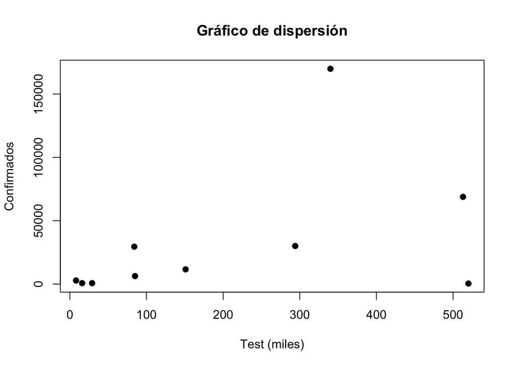

```r
#Crea gráficos de dispersión entre dos vectores. Completar para todos los pares de variables
plot(covid$test.miles, covid$confirmados, main="Gráfico de dispersión",
   xlab="Test (miles)", ylab="Confirmados", pch=19)
```

Considerando la poca cantidad de casos en nuestra base de datos (sólo 10 países), es probable que los gráficos de dispersión no muestren con claridad una relación. Por esto, es importante calcular el coeficiente de correlación, que permite cuantificar a) la presencia de una relación; b) la dirección de la relación (directa o inversa); y c) la fuerza de la relación.

```r
#Para obtener el coeficiente de correlación para cada par de variables, se puede utilizar la función "cor()", pero solo con vectores
covid.cor <- subset(covid, select = c(pob.mm,test.miles,confirmados,muertes,activos))

cor(covid.cor, use="complete.obs", method="pearson") #Esta función la podemos correr automáticamente o guardarla dentro de un objeto como se describe a continuación.
```

```
##                pob.mm test.miles confirmados   muertes   activos
## pob.mm      1.0000000  0.3198874   0.9065769 0.9533470 0.8714504
## test.miles  0.3198874  1.0000000   0.4364697 0.2910991 0.4479553
## confirmados 0.9065769  0.4364697   1.0000000 0.9645778 0.9938714
## muertes     0.9533470  0.2910991   0.9645778 1.0000000 0.9469945
## activos     0.8714504  0.4479553   0.9938714 0.9469945 1.0000000
```

```r
correlacion <- cor(covid.cor, use="complete.obs", method="pearson")
print(cor)
```

[output not shown]

## Bonus: mejora la presentación de tus tablas

**NOTA: Para más información sobre el uso de R, existen diversas fuentes, aunque la mayoría en inglés. Acá les dejo la página de *StackOverflow* en español, que es un foro muy conocido en el mundo anglosajón para el uso de R (y otras herramientas de programación) y recientemente acaba de lanzar su foro en español: https://es.stackoverflow.com/?utm_source=stackoverflow.com&utm_medium=ad&utm_campaign=soes-1&utm_content=sb-idioma**